# Grandes Amostras

Alexandre Nicolella

nicolella@usp.br

FEARP/USP

2026-04-27

# Grandes Amostras

## Introdução: Inferência

### Objetivo

- Um processo de levantamento de informações é em geral caro e em muitas situações é destrutivo.
- Censo demográfico de 2010 custou R$ 1,3 bilhões, ou aproximadamente R$ 2,2 bi em reais de 2020.
- Pesquisas eleitorais em 2018 tiveram uma média de custo de R$ 53 o questionário
- Objetivo:

**A partir de uma amostra da população realizar inferência sobre toda a população.**

## Exemplos do príncipio no dia a dia

Pense nessas situações:

- Para medir a glicose muitos pacientes usam uma gota de sangue e um pequeno aparelho. A partir dele sabem quanto tem no corpo todo, basta uma gota para termos boa certeza de quanto é taxa de glicose!
- Para saber se a quantidade de sal está adequada em uma grande panela de arroz, basta uma pequena colher de chá para termios uma boa certeza!
- Abacaxis às vezes são vendidos em caminhões na rua. Quando paramos provamos e são doces. Compramos 4 por 10. Qual a certeza que esses que vc está levando estejam também doces? É diferente das situações anteriores?

## Definições: População e amostra

**DEFINIÇÃO**

**População:** Totalidade das observações sob Investigação

**Amostra:** Subconjunto da população observado

- A definição da população depende da pergunta de pesquisa ou análise.

**Quem define a população é o objetivo do seu trabalho.**

## Definições: Amostragem Aleatória Simples

- amostragem com viés:

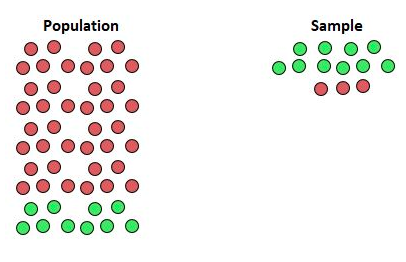

Amostragem tendenciosa

## Definições: Amostragem Aleatória Simples

- amostragem não viesada:

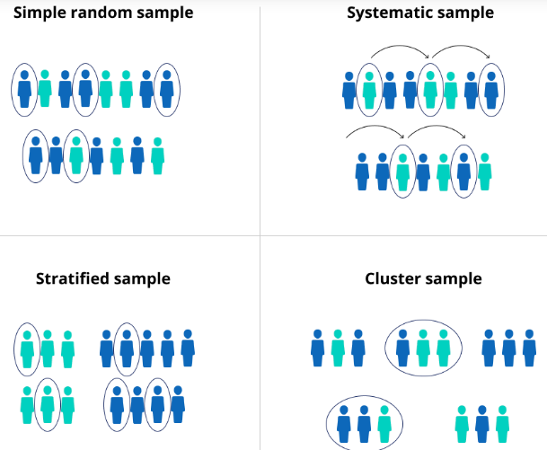

Tipos de amostragem aleatórias

## Definições: Amostragem Aleatória Simples

**DEFINIÇÃO**

Considere uma amostra de tamanho n de uma população $f(x)$,tal que $i=1,...,n$ , onde $X_i$ é a i-ésima medição de $X$.

Assim, chamamos de **Amostra Aleatória Simples** o conjunto de n variáveis aleatóridas independentes $X_i,...,X_n$, cada uma com a mesma distribuição de probabilidade de $X$, ou seja, $f(x)$.

- Garantir que cada medida $X_i$ seja feita da mesma maneira
- $X_i,...,X_n$ é independemente e identicamente distribuída (iid).
- $X_i$ são variáveis aleatórias e $(x_i, ..., x_n)$ os valores correspondentes

## Graficamente: A.A.S.

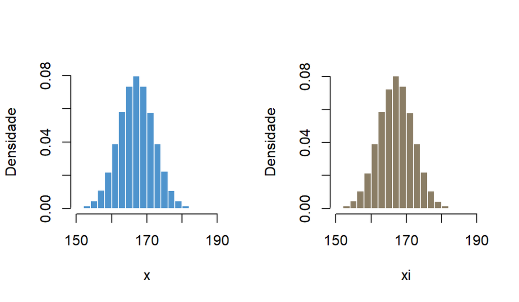

Distribuição de probabilidade de X e da primeira medição de X, ou seja, Xi

## Exemplo: AAS

**EXEMPLO**

Seja X a altura média dos alunos. Temos uma amostra de tamanho n=30 que é representada por: ($X_1, X_2, ..., X_{30}$) as medições e ($x_1, x_2,..., x_{30}$) as alturas observadas

Se a altura $X$ for uma v.a. com fdp $f(x)$ então cada mensuração $X_i$ terá a mesma distribuição $f(x)$ e a função de densidade conjunta de ($X_1, X_2, ..., X_{30}$) será:

$$\begin{array}{ccc}
g (x_1,...,x_{30})= f(x_1) f(x_2)...f(x_{30})
\end{array}$$

ou

$$\begin{array}{ccc}
q(x_1,...,x_{30})= p(x_1) p(x_2)...p(x_{30})
\end{array}$$
Pois são $iid$

## Estatística e Parâmetro

**DEFINIÇÃO**

**Parâmetro:** Medida que descreve uma característica da população.

- Os parâmetros definem as características de uma população
- Qual a renda média da população
- Qual o desemprego médio da população
- Qual a expectativa de vida média na população

## Estatística e Parâmetro

**DEFINIÇÃO**

**Estatística** é uma característica de uma amostra, ou seja, é uma função de seus elementos ($X_1, X_2, ..., X_{n}$).

**DEFINIÇÃO**

Seja $X_1, X_2, ..., X_{n}$ uma A.A.S. de $X$. Sejam $x_1, x_2,..., x_{n}$ os valores medidos a cada para cada medição de $X$. Seja $H$ uma função real. Podemos definir uma estatística como:

$$\begin{array}{ccc}
T= H (X_1, X_2, ..., X_{n})
\end{array}$$

Para a amostra e toma o valor particular:

$$\begin{array}{ccc}
t= H (x_1, x_2, ..., x_{n})
\end{array}$$

## Estatística e Parâmetro

- T é uma variável aleatória e, portanto, possuirá uma distribuição de probabilidade, chamada de distribuição amostral de T. Alguns exemplos de T:

$$\begin{array}{ccc}
Média: \ \overline{X}=\frac{\sum_{i=1}^{n} X_i}{n}
\end{array}$$

$$\begin{array}{ccc}
Variância: \ S^{2}= \frac{1}{n-1} \sum_{i=1}^{n} (X_i - \overline{X})^{2}
\end{array}$$

$$\begin{array}{ccc}
X_{(1)}: Min\{X_1, ..., X_n\}
\end{array}$$

## Estatística e Parâmetro

- Vejamos a tabela abaixo que já faz uma primeira associação entre estatística e parâmetro:

| Parâmetro |  | Estatística |  |
| --- | --- | --- | --- |
| Esperança | $E(X)=\mu$ | $\bar{X}$ | Média |
| Variância Pop. | $Var(X)=\sigma^2$ | $S^2;\sigma^2$ | Variância Amostral |
| Mediana Pop. | Md | md | Mediana Amostral |
| Proporção Pop. | p | $\hat{p}$ | Proporção Amostral |

Tabela 1 - Parâmetros populacionais e as Estatísticas associadas

- Em geral, parâmetros são representados por letras gregas e estatística por letras do alfabeto latino
- Ou se utilizamos para ambos nosso alfabeto e um chapéu para indicar que é uma estatística

## Distribuições Amostrais

## Introdução

Nosso objetivo agora é ser mais específico:

**Fazer uma afirmativa sobre o parâmetro, característica da população, por meio de um estatística, característica da amostra.**

- Utilizamos uma estatística amostral $T$ para inferir o parâmetro populacional $\Theta$
- Como $T$ é uma variável aleatória e possui distribuição de probabilidade, precisamos saber:

$\rightarrow$ Qual a distribuição de T?

$\rightarrow$ Quais as propriedades ou característica das distribuições amostrais?

## Distribuição Amostral da Média

Temos os parâmetros populacionais conhecidos:

$$\begin{array}{ccc}
E(X)=\mu
\\
\\
Var(X)=\sigma^{2}
\end{array}$$

Intuição:

$\rightarrow$ Extraímos todas as possíveis amostras de tamanho n da população

$\rightarrow$ Então calculamos $\overline{X}$ para cada uma das amostras

Assim:

$$\begin{array}{ccc}
E(\overline{X})=X
\\
\\
Var(\overline{X})=S_{\overline{X}}^{2} = \frac{Var(X)}{n}
\end{array}$$

## Distribuição Amostral da Média

**TEOREMA**

Seja $X$ uma v.a. com parâmetros $\mu$ e $\sigma^{2}$. Seja $(X_1, X_2, ..., X_{n})$ uma A.A.S. de $X$. Então:

$$\begin{array}{ccc}
E(\overline{X})=\mu
\\
\\
Var(\overline{X})= \frac{\sigma^{2}}{n}
\end{array}$$

**Demonstração:**

Para $(X_1, X_2, ..., X_{n})$ independentes temos que:

$$\begin{array}{ccc}
E(\overline{X})=\frac{1}{n} \{ E(X_1)+ ...+ E(X_n) \} =\frac{ n \mu}{n}=\mu
\\
\\
Var(\overline{X})=\frac{1}{n^{2}} \{ Var(X_1)+ ...+ Var(X_n) \}= \frac{1}{n^{2}} n \sigma^{2}= \frac{\sigma^{2}}{n}
\end{array}$$

## Graficamente: Distribuição Amostral da Média

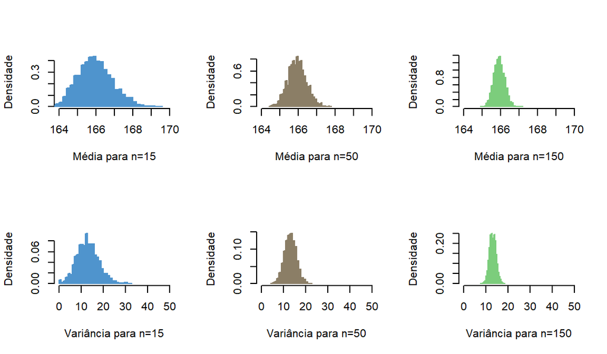

Distribuição amostral da média para diferentes tamanos amostrais

## Calculando Esperança e Variância da Dist. Amostral da Média

- Vamos agora calcular $E(\overline{X})$

```
[1] 165.9596
```

```
[1] 165.9507
```

```
[1] 165.9317
```

## Calculando Esperança e Variância da Dist. Amostral da Média

- Pode-se verificar também a variância amostral $Var(\overline{X})=\frac{\sigma^{2}}{n}$. Vejamos:

```
[1] 0.9067206
```

```
[1] 0.2591606
```

```
[1] 0.08781269
```

## Distribuição de X e da $\overline{X}$

- Resultado válido para qualquer distribuição de $X$. Suponha $X$ com dist $\chi^2$.

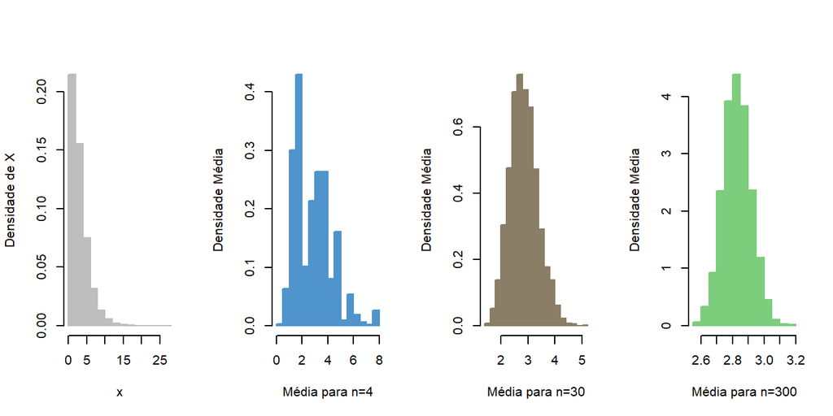

Distribuição amostral da média para diferentes tamanos amostrais

## Distribuição Amostral da Variância

- A Variância Amostral também é uma variável aleatória.
- Os gráficos anteriores mostram a distribuição de $Var(X_i)$ para diferentes tamanhos amostrais

**DEFINIÇÃO**

A variância amostral:

$$\begin{array}{ccc}
Variância: \ S^{2}= \frac{1}{n-1} \sum_{i=1}^{n} (X_i - \overline{X})^{2}
\end{array}$$

possui distribuição $\chi ^{2}$ se $X$ possui distribuição normal.

-Para $n$ grande podemos aproximar a $\chi ^{2}$ por uma distribuição normal

## Distribuição amostral da proporção

Considere uma amostra $X_1, X_2, ..., X_{n}$ que assume os valores:

$x_i=1$: sucesso

$x_i=0$: fracasso

para $i=1,2...,n$.

Seja $p$ a probabilidade de sucesso. Então a proporção amostral pode ser calculada como:

$$\begin{array}{ccc}
\hat{p}= \frac{\sum_{i=1}^{n} X_i}{n}
\end{array}$$

## Distribuição amostral da proporção

Seja $Y=\sum_{i=1}^{n} X_i$. Então $Y$ possui distribuição Binomial com parâmetros $E(Y)=n.p$ e $Var(Y)=np(1-p)$.

Então, as caracteriticas da proporção, $\hat{p}$, será :

$$\begin{array}{ccc}
E(\hat{p})= \frac{n p}{n} = p
\\
\\
Var(\hat{p})= \frac{1}{n^{2}} n p (1-p)= \frac{p(1-p)}{n}
\end{array}$$

Para n grande a distribuição de $\hat{p}$ é aproximadamente Normal (pela aproximação da binomial pela Normal).

# Modos de Convergência

## Introdução

- Uma sequência de variáveis aleatórias $X_1,X_2,...,X_n$ caminha ou converge na direção de $X$.
- Queiramos saber o valor de $X$, fazemos uma medida via $X_1$
- Aumentamos o número de medidas para $X_2$ e observamos se chega mais próximo
- Constinuamos até $X_n$ e vemos se essa sequência de medidas vai convergindo para $X$.
- Veremos aqui 3 tipos de convergência.
1. Convergência em probabilidade
2. Convergência em Média Quadratica
3. Convergência em Distribuição

## Convergência de uma sequência numérica

**DEFINIÇÃO**

**Convergência:**

Uma sequência de números reais $\{\alpha_i\}$ $i=1,2,..,n$ converge para um número real $\alpha$ se para qualquer $\varepsilon>0$ existe um inteiro N onde para todo $n>N$ tem-se:

$$\begin{array}{ccc}
|\alpha_n - \alpha |<\varepsilon
\end{array}$$

Assim:

$\alpha_n \rightarrow \alpha$ quando $n \rightarrow \infty$ ou

$lim_{n \rightarrow \infty} \alpha_n = \alpha$

- No caso de variáveis aleatórias, essa definição é não adequada.

## Convergência em Distribuição e o Teorema do Limite Central.

- Forma mais fraca de convergência, a fda de $X_n$ converge para a fda de $X$. Formalmente:

**DEFINIÇÃO**

**Convergência em Distribuição**

Uma sequência de v.a. $\{X_i\}$ $i=1,2,..,n$ converge para $X$ em distribuição se a função de distribuição acumulada $F_{X_n}$ de $X_i$ converge para a f.d.a. $F_X$ de $X$ em cada ponto da F. Em outras palavras:

$X_n \overset{d}{\rightarrow} X$ ou

$\lim_{n \rightarrow\infty}F_{X_n}(x)=F_{X}(x)$ é a distribuição limite de $X_n$.

## Teorema do Limite Central (TLC): Aplicação da Convergência em Distribuição.

- Um dos resultados mais importantes em estatística
- Afirma que a soma de um grande número de variáveis aleatórias possui distribuição normal.
- Uma sequência $X_1, X_2, ...., X_n$ a qual possui a mesma distribuição de $X$.
- A média $\overline{X}$, é uma soma de variáveis aleatórias, possui $E(\overline{X})=\mu$ e a variância $Var(\overline{X})=\frac{\sigma^2}{n}$.
- Podemos normalizar a variável aleatória $\overline{X}$, ou seja $Z_n$:

$$\begin{array}{ccc}
Z_n=\frac{\overline{X}_n- E(\overline{X}_n)}{\sqrt{Var(\overline{X}_n)}}
\end{array}$$

## Teorema do Limite Central

- Dessa forma podemos fazer a seguinte definição:

**DEFINIÇÃO**

**Teorema do Limite Central**

Seja $X_1, X_2,...,X_n$ uma sequência de variáveis aleatórias com $E(X_i)=\mu$ e $Var(X_i)=\sigma^2$. A variável $\overline{X}$ normalizada:
$$\begin{array}{ccc}
Z_n=\frac{\overline{X}_n- E(\overline{X}_n)}{\sqrt{Var(\overline{X}_n)}} =\frac{X_1+X_2+,...+X_n-n\mu}{\frac{\sigma}{\sqrt{n}}}
\end{array}$$
converge em distribuição para uma normal padrão quando $n$ vai para o infinito, assim:

$\lim_{n \rightarrow\infty}P(Z_n \leq x)=\Phi(x)$ para todo $x \in \mathbb{R}$

Portanto,
$$\begin{array}{ccc}
Z_n \overset{d}{\rightarrow} N(0,1)
\end{array}$$

## Teorema do Limite Central

- Temos a distribuição assintótica de $Z_n$ (a qual se aproxima quando n é grande), será:

$$\begin{array}{ccc}
Z_n \overset{a}{\sim } N(0,1)
\end{array}$$

- Isso implica que a distribuição assintótica da sequência $\overline{X}_n$ é:

$$\begin{array}{ccc}
\overline{X}_n\overset{a}{\sim }N(E(\overline{X_n}),Var(\overline{X_n}))
\end{array}$$

## TLC: Aproximação da Binomail pela Normal

Uma variável com distribuição Binomial $X$ é a soma de v.a. Bernoulli iid $\{Y_i\}$ tal que $X= \sum Y_i$. Sendo que $Y_i=1$ com probabilidade $p$ e $Y_i=0$ com probabilidade $(1-p)$.

$\hat{p}=\frac{X}{n}$

Assim, se as condições do TLC são satisfeitas, com $E(Y_i)=p$, $Var(Y_i)=(1-p)p$ e $\hat{p}=\frac{X}{n}$ então:

$$\begin{array}{ccc}
\frac{\frac{X}{n}-p} {\sqrt{(1-p)p/n}}\overset{d}{\rightarrow} N(0,1)
\end{array}$$

Assim:

$$\begin{array}{ccc}
\frac{X}{n} \overset{a}{\sim } N(p, pq/n)
\end{array}$$

Ou:

$$\begin{array}{ccc}
X \overset{a}{\sim } N(np, npq)
\end{array}$$

## Convergência em Probabilidade e a Lei dos Grandes Números

- É um modo de convergência mais forte do que a convergência em distribuição, muitas vezes chamada de convergência estocástica. Vejamos a definição:

**DEFINIÇÃO**

**Convergência em Probabilidade:**

Uma sequência de v.a. $X_1,X_2,,...,X_n$ converge em probabilidade para uma v.a. $X$, ou seja,

$X_n \overset{p}{\rightarrow} X$ quando $n \rightarrow \infty$, se:

$lim_{n \rightarrow \infty} P(|X_n - X |\geq \varepsilon) = 0$ ou

$plim_{n \rightarrow \infty} X_n = X$

## A Lei dos Grandes Números (LGN): Aplicação da Convergência em Probabilidade

- Lei Fraca dos Grandes Números: Teorema que descreve o resultado de um experimento realizado um grande número de vezes.

**DEFINIÇÃO**

**Lei Fraca dos Grandes Números**

Dada uma sequência da v.a. $X_i$ e $\overline{X}_n=\frac{1}{n} \sum X_i$, a Lei Fraca Dos Grandes Números coloca que $\overline{X}_n - E(\overline{X}_n)$ converge para 0 em probabilidade. Portanto:

$\overline{X}_n - E(\overline{X}_n) \overset{p}{\rightarrow} 0$

ou

$\overline{X}_n \overset{p}{\rightarrow} E(\overline{X}_n)=\mu$

## A Lei dos Grandes Números (LGN): Aplicação da Convergência em Probabilidade

**TEOREMA**

Seja uma sequência $X_1,X_2,...,X_n$ iid com $E(X_i)=\mu$ e $Var(X_i)=\sigma^2$ . Então, $\overline{X_n} \overset{p}{\rightarrow} \mu$ quando $n $.

**Prova:**

Utilizando a desigualdade de Tchebycheff:

$$\begin{array}{ccc}
P(|\overline{X} - \mu|< \varepsilon ) \geq 1-\frac{\sigma^{2}}{\varepsilon^{2} n}
lim_{n \rightarrow \infty} P(|\overline{X} - \mu|< \varepsilon ) = 1
\end{array}$$

Portanto:

$\overline{X} \overset{P}{\rightarrow} \mu$ ou $plim \overline{X} = \mu$

## A Lei dos Grandes Números (LGN): em palavras

**O significado de $X_n$ convirgir para $\mu$, é que com uma amostra cada vez maior existe uma probabilidade muito alta de que a média das observações esteja próxima do verdadeiro parâmetro populacional, ou seja, a esperança.**

## Convergência em Média Quadrática

- É um tipo de convergência mais forte que a de probabilidade e de distribuição.

**DEFINIÇÃO**

**Convergência em Média Quadrática**

Uma sequência de v.a. $X_1,X2,...,X_n$ converge para $X$ em média quadrática se:

$$\begin{array}{ccc}
lim_{n \rightarrow \infty} E(X_n - X)^{2} = 0
\end{array}$$

Tal que:

$X_n \overset{M}{\rightarrow} X$

## Relação entre as convergências

-Existe uma relação entre os diversos tipos de convergência. Vejamos

**TEOREMA**

$X_n \overset{M}{\rightarrow} X \Rightarrow X_n \overset{P}{\rightarrow} X$

$X_n \overset{p}{\rightarrow} X \Rightarrow X_n \overset{d}{\rightarrow} X$

O que implica:

$X_n \overset{M}{\rightarrow} X \Rightarrow X_n \overset{p}{\rightarrow} X \Rightarrow X_n \overset{d}{\rightarrow} X$

## Determinação do tamanho da amostra

## Introdução:

Iremos considerar aqui apenas a técnica de amostrage alatatória simples. Nosso objetivo é dar a intuição do processo de amostragem e não ensinar a fazer design de pesquisa de campo. Existem disciplinas específicas para isso.

Duas medidas importantes a serem consideradas.

1. Distância Máxima tolerável entre a estimativa e o parâmetro real: $d$
2. A probabilidade de que $d$ seja maior que o tolerável: $\alpha$

## Tamanho da amostra com $\sigma$ conhecido

- Considere a desigualdade de Tchebycheff:
  $$\begin{array}{ccc}
  P(|\overline{X} - \mu| \leq \varepsilon ) \geq 1-\frac{\sigma^{2}}{\varepsilon^{2} n}
  \end{array}$$
- Considerando $\varepsilon=d$, $\frac{\sigma^{2}}{\varepsilon^{2} n}=\alpha$ e trabalhando no limite inferior tolerável (na igualdade)

## Tamanho da amostra com $\sigma$ conhecido

- Temos:

$$\begin{aligned}
P(|\overline{X} - \mu| \leq d) &= 1 - \alpha \\
P(-d \leq \overline{X} - \mu \leq d) &= 1 - \alpha \\
P\left(-\frac{d}{\sigma/\sqrt{n}} \leq Z \leq \frac{d}{\sigma/\sqrt{n}}\right) &= 1 - \alpha \\
P\left(-\frac{d\sqrt{n}}{\sigma} \leq Z \leq \frac{d\sqrt{n}}{\sigma}\right) &= 1 - \alpha \\
P(-Z_c \leq Z \leq Z_c) &= 1 - \alpha
\end{aligned}$$

Portanto, igualando o termo crítico:

$$Z_c = \frac{d\sqrt{n}}{\sigma} \implies n = \frac{\sigma^{2}Z_c^{2}}{d^{2}}$$

- Observa-se que o tamanho da amostra não tem relação com o tamanho da população.

## Tamanho da amostra com $\sigma$ conhecido: Exemplo

**EXEMPLO**

Uma pesquisa de satisfação foi feita com os funcionários de uma empresa. O índice vai de 0 a 100 e sabe-se que o desvio padrão é 30.

Qual o tamanho da amostra de entrevistados, considerando um nível de tolerância $d=1,5$ unidades, com probabilidade $1-\alpha=92,81\%$?

**Resposta:**

Na tabela da distribuição normal padrão:
$$\begin{array}{ccc}
1 -\alpha = 0,9281 \rightarrow Z_c=1,8
\end{array}$$

Como d=1,5 então:

$$\begin{array}{ccc}
n=(\frac{1,8 . 30}{1,5})^{2}\cong 1.296
\end{array}$$

## Tamanho da amostra com população finita

- Se a população for finita a independência entre os elementos $X_i$ não é válida. Segue que:

$$\begin{array}{ccc}
Var(\overline{X}) = \frac{\sigma^{2}}{n}
\end{array}$$

é caso particular de:

$$\begin{array}{ccc}
Var(\overline{X}) = \sigma^{2}(\frac{1}{n}-\frac{1}{N})
\end{array}$$

- Onde N é o tamanho populacional. Assim, para N finito e conhecido basta utilizar:

$$\begin{array}{ccc}
n' = \frac{n}{1+ n/N}
\end{array}$$

## Tamanho da amostra com população finita

- Note que se $n$ for muito menor que $N$ então $n' \rightarrow n$ e

$$\begin{array}{ccc}
Var(\overline{X}) = \sigma^{2}(\frac{1}{n}-\frac{1}{N}) \rightarrow \frac{\sigma^{2}}{n}
\end{array}$$

- Ou seja, converge para a amostragem anterior para população infinita.

## Tamanho da amostra com $\sigma$ desconhecido: média amostral

- Como não temos $\sigma$ fazemos uma amostra piloto com $n_1$ elementos e estimamos o desvio padrão da seguinte maneira:

$$\begin{array}{ccc}
S_1=\sqrt{\frac{\sum (X_i - \overline{X})^{2}}{n-1}}
\end{array}$$

- Assim pode-se calcular: $n=\frac{S_1 ^{2} Zc^{2}}{d^{2}}$
- Temos já $n_1$ elementos agora podemos complementar até chegar a $n$

## Tamanho da amostra para Proporção populacional

- Agora queremos garantir que:

$$\begin{array}{ccc}
P(|\hat{p} - p|\leq d) = 1 - \alpha
\end{array}$$

- O tamanho da amostra será tal que:

$$\begin{array}{ccc}
n=\frac{ Z_{c}^{2}}{d^{2}} p (1-p)
\end{array}$$

- se não sabemos nada considerar $p=0,5$, esse irá gerar a maior amostra para dado $\alpha$ e $d$

## Tamanho da amostra para Proporção populacional

**O exemplo no R:**

- Vejamos como ficaria o tamanho amostral para uma pesquisa eleitoral onde consideramos que $p=0.4$, $1-p=0.6$, $1-\alpha=0,95$ e iremos considerar dois $d$, margem de erro. Ou seja, a primeira é dois pontos percentuais para mais ou menos, o segundo 0,5 pontos percentuais.
- Lembrando que o custo do questionário é de R$53,00.

```
[1] 2304.96
```

```
[1] 122162.9
```

```
[1] 36879.36
```

```
[1] 1954606
```